# Example Code

George Williford

9/12/2019

```r
library(tvcure)
library(snow)
library(foreach)
library(doParallel)
library(doSNOW)
library(smcure)
data(e1684)
```

# Estimate model

```r
cl <- makeCluster(4, "SOCK"); registerDoSNOW(cl)
pd <- tvcure(Surv(FAILTIME, FAILCENS) ~ TRT + SEX + AGE, cureform = ~ TRT + SEX + AGE, data = e1684, model = "ph", parallel = T)
```

# Summary of model

```r
summary(pd)
```

```
## Call:
## tvcure(formula = Surv(FAILTIME, FAILCENS) ~ TRT + SEX + AGE,
##     cureform = ~TRT + SEX + AGE, model = "ph", data = e1684,
##     parallel = T)
##
##           GLM Coefficients Standard Error    Z-Score      p-value
## Intercept       1.14213789      0.1755872  6.5046772 7.786038e-11
## TRT            -0.57648463      0.2481878 -2.3227757 2.019121e-02
## SEX            -0.07179275      0.2563457 -0.2800622 7.794298e-01
## AGE             0.01266512      0.0100905  1.2551524 2.094234e-01
##
##     Hazard Coefficients Standard Error    Z-Score   p-value
## TRT        -0.139433795    0.148778508 -0.9371904 0.3486606
## SEX         0.105909978    0.144088665  0.7350334 0.4623192
## AGE        -0.006588678    0.005979657 -1.1018489 0.2705274
##
## n = 284 with 196 failures
## Model converged in 10 iterations
## Variance estimates based on 100 successful boostrap replications
```

# Create a table (can be exported to latex using the xtable package)

```r
tvtable(pd, format = "wide", qi = "se", stars = T, digits = 3)
```

```
##                        Incidence Coef. Std. Error   Hazard Coef.
## Intercept              "1.142"         "(0.176)***" ""
## TRT                    "-0.576"        "(0.248)*"   "-0.139"
## SEX                    "-0.072"        "(0.256) "   "0.106"
## AGE                    "0.013"         "(0.01) "    "-0.007"
## Number of Observations "284"           ""           ""
## Number of Failures     "196"           ""           ""
##                        Std. Error
## Intercept              ""
## TRT                    "(0.149) "
## SEX                    "(0.144) "
## AGE                    "(0.006) "
## Number of Observations ""
## Number of Failures     ""
```

# Plots

This code plots the baseline survivor function for the entire population.

```r
testpred1a <- prediction2(pd, variable = "TRT", values = c(0:1), type = "basesurv", CI = T, nsims = 100); testpred1a
```

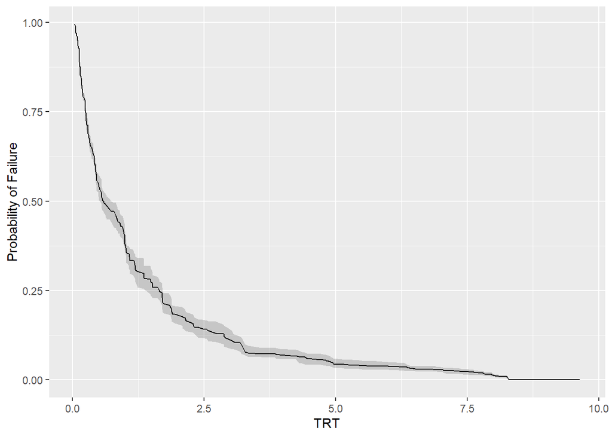

This code plots the probability that an individual is not cured for at different values of TRT.

```r
testpred1d <- prediction2(pd, variable = "TRT", values = c(0:1), type = "uncureprob", CI = T, nsims = 100); testpred1d
```

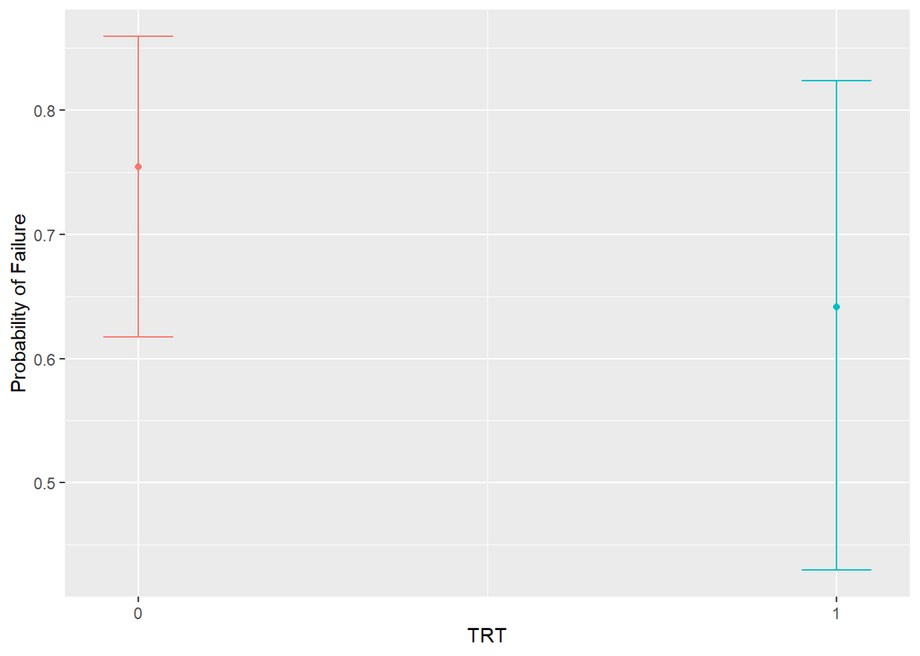

The following code plots the survival function for only those individuals who are not cured, i.e., those that will fail. In other words, conditional on the probability that an individual with TRT = 0 fails, what is the survivor function for individuals with TRT = 0. This code plots the survivor functions for both 0 and 1.

```r
testpred1b <- prediction2(pd, variable = "TRT", values = c(0:1), type = "suncure", CI = T, nsims = 100); testpred1b
```

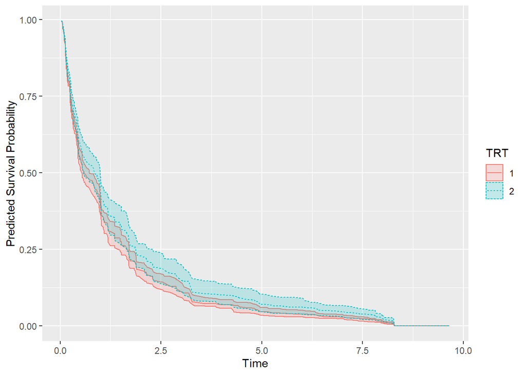

The following code plots the survival function for the entire population, both those that will fail and those that won’t. In other words, what is the survivor function for all individuals when TRT = 0 (accounting for both the probability of failure and the effect on survivor time for uncured patients). This code plots the survivor functions for both 0 and 1.

```r
testpred1c <- prediction2(pd, variable = "TRT", values = c(0:1), type = "spop", CI = T, nsims = 100); testpred1c
```

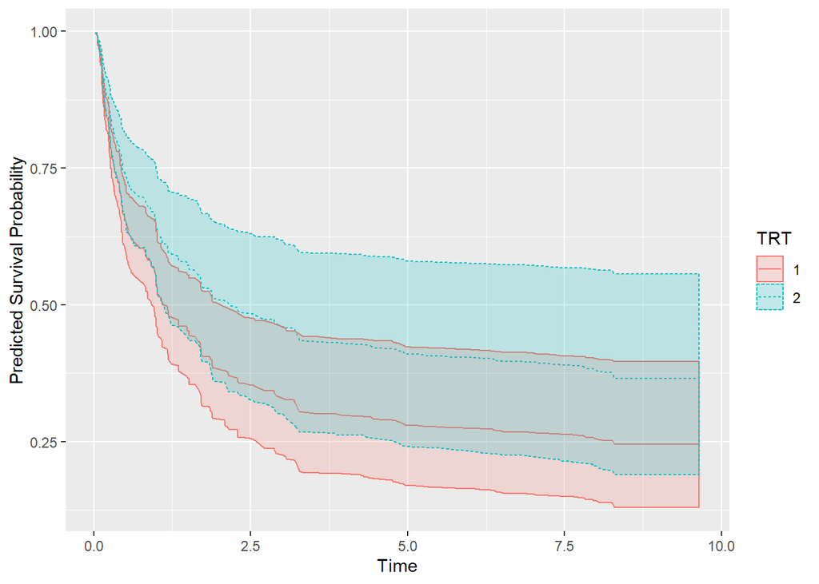